# R Notebook

Anthony Davidson

January 2022

The acknowledgments, preface, dedication, and abstract are added into the PDF version automatically by inputting them in the YAML at the top of this file. Alternatively, you can put that content in files like 00–prelim.Rmd and 00-abstract.Rmd like done below.

# Preliminary Content

## Acknowledgements

I want to thank a few people.

## Preface

This is an example of a thesis setup to use the reed thesis document class (for LaTeX) and the R bookdown package, in general.

## Dedication

You can have a dedication here if you wish.

## Abstract

# Introduction

Welcome to the *R Markdown* thesis template. This template is based on (and in many places copied directly from) the Reed College LaTeX template, but hopefully it will provide a nicer interface for those that have never used TeX or LaTeX before. Using *R Markdown* will also allow you to easily keep track of your analyses in **R** chunks of code, with the resulting plots and output included as well. The hope is this *R Markdown* template gets you in the habit of doing reproducible research, which benefits you long-term as a researcher, but also will greatly help anyone that is trying to reproduce or build onto your results down the road.

Hopefully, you won’t have much of a learning period to go through and you will reap the benefits of a nicely formatted thesis. The use of LaTeX in combination with *Markdown* is more consistent than the output of a word processor, much less prone to corruption or crashing, and the resulting file is smaller than a Word file. While you may have never had problems using Word in the past, your thesis is likely going to be about twice as large and complex as anything you’ve written before, taxing Word’s capabilities. After working with *Markdown* and **R** together for a few weeks, we are confident this will be your reporting style of choice going forward.

**Why use it?**

*R Markdown* creates a simple and straightforward way to interface with the beauty of LaTeX. Packages have been written in **R** to work directly with LaTeX to produce nicely formatting tables and paragraphs. In addition to creating a user friendly interface to LaTeX, *R Markdown* also allows you to read in your data, to analyze it and to visualize it using **R** functions, and also to provide the documentation and commentary on the results of your project. Further, it allows for **R** results to be passed inline to the commentary of your results. You’ll see more on this later.

**Who should use it?**

Anyone who needs to use data analysis, math, tables, a lot of figures, complex cross-references, or who just cares about the final appearance of their document should use *R Markdown*. Of particular use should be anyone in the sciences, but the user-friendly nature of *Markdown* and its ability to keep track of and easily include figures, automatically generate a table of contents, index, references, table of figures, etc. should make it of great benefit to nearly anyone writing a thesis project.

**For additional help with bookdown**

Please visit [the free online bookdown reference guide](https://bookdown.org/yihui/bookdown/).

# R Markdown Basics

Here is a brief introduction into using *R Markdown*. *Markdown* is a simple formatting syntax for authoring HTML, PDF, and MS Word documents. *R Markdown* provides the flexibility of *Markdown* with the implementation of **R** input and output. For more details on using *R Markdown* see https://rmarkdown.rstudio.com.

Be careful with your spacing in *Markdown* documents. While whitespace largely is ignored, it does at times give *Markdown* signals as to how to proceed. As a habit, try to keep everything left aligned whenever possible, especially as you type a new paragraph. In other words, there is no need to indent basic text in the Rmd document (in fact, it might cause your text to do funny things if you do).

## Lists

It’s easy to create a list. It can be unordered like

- Item 1
- Item 2

or it can be ordered like

1. Item 1
2. Item 2

Notice that I intentionally mislabeled Item 2 as number 4. *Markdown* automatically figures this out! You can put any numbers in the list and it will create the list. Check it out below.

To create a sublist, just indent the values a bit (at least four spaces or a tab). (Here’s one case where indentation is key!)

1. Item 1
2. Item 2
3. Item 3
   - Item 3a
   - Item 3b

## Line breaks

Make sure to add white space between lines if you’d like to start a new paragraph. Look at what happens below in the outputted document if you don’t:

Here is the first sentence. Here is another sentence. Here is the last sentence to end the paragraph. This should be a new paragraph.

*Now for the correct way:*

Here is the first sentence. Here is another sentence. Here is the last sentence to end the paragraph.

This should be a new paragraph.

## R chunks

## Inline code

If you’d like to put the results of your analysis directly into your discussion, add inline code like this:

> The `cos` of $2 \pi$ is 1.

Another example would be the direct calculation of the standard deviation:

> The standard deviation of `speed` in `cars` is 5.2876444.

One last neat feature is the use of the `ifelse` conditional statement which can be used to output text depending on the result of an **R** calculation:

> The standard deviation is less than 6.

Note the use of `>` here, which signifies a quotation environment that will be indented.

As you see with `$2 \pi$` above, mathematics can be added by surrounding the mathematical text with dollar signs. More examples of this are in Mathematics and Science if you uncomment the code in Math.

## Including plots

You can also embed plots. For example, here is a way to use the base **R** graphics package to produce a plot using the built-in `pressure` dataset:

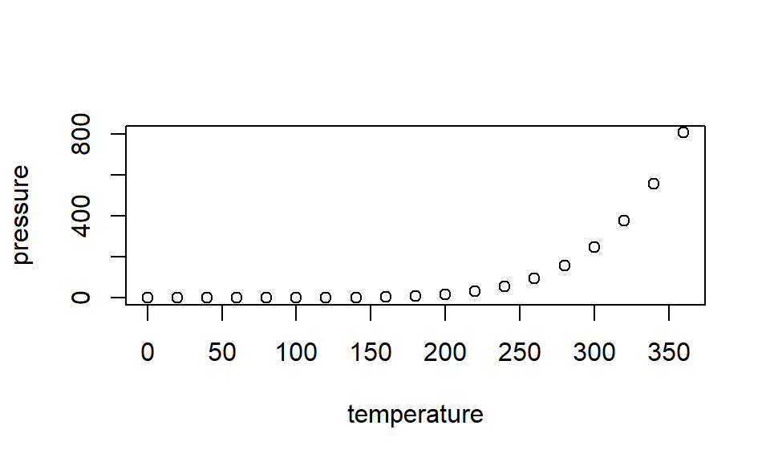

Note that the `echo=FALSE` parameter was added to the code chunk to prevent printing of the **R** code that generated the plot. There are plenty of other ways to add chunk options (like `fig.height` and `fig.width` in the chunk above). More information is available at https://yihui.org/knitr/options/.

Another useful chunk option is the setting of `cache=TRUE` as you see here. If document rendering becomes time consuming due to long computations or plots that are expensive to generate you can use knitr caching to improve performance. Later in this file, you’ll see a way to reference plots created in **R** or external figures.

## Loading and exploring data

Included in this template is a file called `flights.csv`. This file includes a subset of the larger dataset of information about all flights that departed from Seattle and Portland in 2014. More information about this dataset and its **R** package is available at https://github.com/ismayc/pnwflights14. This subset includes only Portland flights and only rows that were complete with no missing values. Merges were also done with the `airports` and `airlines` data sets in the `pnwflights14` package to get more descriptive airport and airline names.

We can load in this data set using the following commands:

```r
# flights.csv is in the data directory
flights_path <- here::here("data", "flights.csv")
# string columns will be read in as strings and not factors now
flights <- read.csv(flights_path, stringsAsFactors = FALSE)
```

The data is now stored in the data frame called `flights` in **R**. To get a better feel for the variables included in this dataset we can use a variety of functions. Here we can see the dimensions (rows by columns) and also the names of the columns.

```r
dim(flights)
```

```
## [1] 12649    16
```

```r
names(flights)
```

```
##  [1] "month"        "day"          "dep_time"     "dep_delay"
##  [5] "arr_time"     "arr_delay"    "carrier"      "tailnum"
##  [9] "flight"       "dest"         "air_time"     "distance"
## [13] "hour"         "minute"       "carrier_name" "dest_name"
```

```r
View(flights)
```

While not required, it is highly recommended you use the `dplyr` package to manipulate and summarize your data set as needed. It uses a syntax that is easy to understand using chaining operations. Below I’ve created a few examples of using `dplyr` to get information about the Portland flights in 2014. You will also see the use of the `ggplot2` package, which produces beautiful, high-quality academic visuals.

We begin by checking to ensure that needed packages are installed and then we load them into our current working environment:

```r
# List of packages required for this analysis
pkg <- c("dplyr", "ggplot2", "knitr", "bookdown")
# Check if packages are not installed and assign the
# names of the packages not installed to the variable new.pkg
new.pkg <- pkg[!(pkg %in% installed.packages())]
# If there are any packages in the list that aren't installed,
# install them
if (length(new.pkg)) {
  install.packages(new.pkg, repos = "https://cran.rstudio.com")
}
# Load packages
library(thesisdown)
library(dplyr)
library(ggplot2)
library(knitr)
```

The example we show here does the following:

- Selects only the `carrier_name` and `arr_delay` from the `flights` dataset and then assigns this subset to a new variable called `flights2`.
- Using `flights2`, we determine the largest arrival delay for each of the carriers.

```r
flights2 <- flights %>%
  select(carrier_name, arr_delay)
max_delays <- flights2 %>%
  group_by(carrier_name) %>%
  summarize(max_arr_delay = max(arr_delay, na.rm = TRUE))
```

A useful function in the `knitr` package for making nice tables in *R Markdown* is called `kable`. It is much easier to use than manually entering values into a table by copying and pasting values into Excel or LaTeX. This again goes to show how nice reproducible documents can be! (Note the use of `results="asis"`, which will produce the table instead of the code to create the table.) The `caption.short` argument is used to include a shorter title to appear in the List of Tables.

```r
kable(max_delays,
  col.names = c("Airline", "Max Arrival Delay"),
  caption = "Maximum Delays by Airline",
  caption.short = "Max Delays by Airline",
  longtable = TRUE,
  booktabs = TRUE
)
```

Table 1: Maximum Delays by Airline

| Airline | Max Arrival Delay |
| --- | --- |
| Alaska Airlines Inc. | 338 |
| American Airlines Inc. | 1539 |
| Delta Air Lines Inc. | 371 |
| Frontier Airlines Inc. | 166 |
| Hawaiian Airlines Inc. | 116 |
| JetBlue Airways | 256 |
| SkyWest Airlines Inc. | 321 |
| Southwest Airlines Co. | 315 |
| United Air Lines Inc. | 319 |
| US Airways Inc. | 347 |
| Virgin America | 366 |

The last two options make the table a little easier-to-read.

We can further look into the properties of the largest value here for American Airlines Inc. To do so, we can isolate the row corresponding to the arrival delay of 1539 minutes for American in our original `flights` dataset.

```r
flights %>%
  filter(
    arr_delay == 1539,
    carrier_name == "American Airlines Inc."
  ) %>%
  select(-c(
    month, day, carrier, dest_name, hour,
    minute, carrier_name, arr_delay
  ))
```

| dep_time | dep_delay | arr_time | tailnum | flight | dest | air_time | distance |
| --- | --- | --- | --- | --- | --- | --- | --- |
| 1403 | 1553 | 1934 | N595AA | 1568 | DFW | 182 | 1616 |

We see that the flight occurred on March 3rd and departed a little after 2 PM on its way to Dallas/Fort Worth. Lastly, we show how we can visualize the arrival delay of all departing flights from Portland on March 3rd against time of departure.

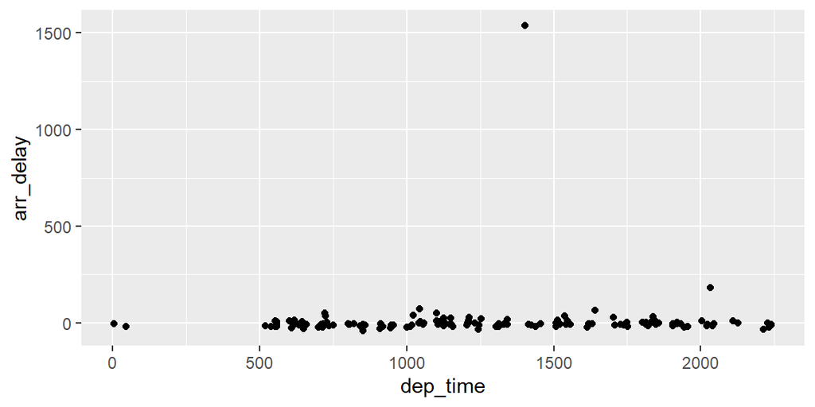

```r
flights %>%
  filter(month == 3, day == 3) %>%
  ggplot(aes(x = dep_time, y = arr_delay)) +
  geom_point()
```

## Additional resources

- *Markdown* Cheatsheet - https://github.com/adam-p/markdown-here/wiki/Markdown-Cheatsheet
- *R Markdown*
  - Reference Guide - https://www.rstudio.com/wp-content/uploads/2015/03/rmarkdown-reference.pdf
  - Cheatsheet - https://github.com/rstudio/cheatsheets/raw/master/rmarkdown-2.0.pdf
- *RStudio IDE*
  - Cheatsheet - https://github.com/rstudio/cheatsheets/raw/master/rstudio-ide.pdf
  - Official website - https://rstudio.com/products/rstudio/
- Introduction to `dplyr` - https://cran.rstudio.com/web/packages/dplyr/vignettes/dplyr.html
- `ggplot2`
  - Documentation - https://ggplot2.tidyverse.org/
  - Cheatsheet - https://github.com/rstudio/cheatsheets/raw/master/data-visualization-2.1.pdf

This project provides a template for writing a PhD thesis in R Markdown, and rendering those files into a PDF formatted according to [the requirements of the University of Washington](https://grad.uw.edu/for-students-and-post-docs/degree-requirements/thesisdissertation/final-submission-of-your-thesisdissertation/). It uses the [University of Washington Thesis class](http://staff.washington.edu/fox/tex/) to convert R Markdown files into a PDF formatted ready for submission at UW. This project was inspired by the thesisdown and bookdown packages.

Currently, the PDF and gitbook versions are fully-functional, and are the focus of this package. The word and epub versions are in development, have no templates behind them, and are essentially calls to the appropriate functions in bookdown.

If you are new to working with `bookdown` and `rmarkdown`, please read over the documentation available in ucdown PDF template (which you can create by following the simple instructions below) and the [bookdown book](https://bookdown.org/yihui/bookdown/).

Under the hood, the [University of Washington Thesis LaTeX template](https://github.com/UWIT-IAM/UWThesis) is used to ensure that documents conform precisely to submission standards. At the same time, composition and formatting can be done using lightweight [markdown](http://rmarkdown.rstudio.com/authoring_basics.html) syntax, and **R** code and its output can be seamlessly included using [rmarkdown](http://rmarkdown.rstudio.com).

# Mathematics and Science

## Math

If you are doing a thesis that will involve lots of math, you will want to read the following section which has been commented out. If you’re not going to use math, skip over or delete this next commented section.

## Chemistry 101: Symbols

Chemical formulas will look best if they are not italicized. Get around math mode’s automatic italicizing in LaTeX by using the argument `$\mathrm{formula here}$`, with your formula inside the curly brackets. (Notice the use of the backticks here which enclose text that acts as code.)

So, $\mathrm{Fe_2^{2+}Cr_2O_4}$ is written `$\mathrm{Fe_2^{2+}Cr_2O_4}$`.

Exponent or Superscript: $\mathrm{O^-}$

Subscript: $\mathrm{CH_4}$

To stack numbers or letters as in $\mathrm{Fe_2^{2+}}$, the subscript is defined first, and then the superscript is defined.

Bullet: CuCl $\bullet$ $\mathrm{7H_{2}O}$

Delta: $\Delta$

Reaction Arrows: $\longrightarrow$ or $\xrightarrow{solution}$

Resonance Arrows: $\leftrightarrow$

Reversible Reaction Arrows: $\rightleftharpoons$

### Typesetting reactions

You may wish to put your reaction in an equation environment, which means that LaTeX will place the reaction where it fits and will number the equations for you.

$$\begin{equation}
\mathrm{C_6H_{12}O_6 + 6O_2} \longrightarrow \mathrm{6CO_2 + 6H_2O}
\tag{1}
\end{equation}$$

We can reference this combustion of glucose reaction via Equation (1).

### Other examples of reactions

$\mathrm{NH_4Cl_{(s)}}$ $\rightleftharpoons$ $\mathrm{NH_{3(g)}+HCl_{(g)}}$

$\mathrm{MeCH_2Br + Mg}$ $\xrightarrow[below]{above}$ $\mathrm{MeCH_2\bullet Mg \bullet Br}$

## Physics

Many of the symbols you will need can be found on the math page https://web.reed.edu/cis/help/latex/math.html and the Comprehensive LaTeX Symbol Guide (https://mirror.utexas.edu/ctan/info/symbols/comprehensive/symbols-letter.pdf).

## Biology

You will probably find the resources at https://www.lecb.ncifcrf.gov/~toms/latex.html helpful, particularly the links to bsts for various journals. You may also be interested in TeXShade for nucleotide typesetting (https://homepages.uni-tuebingen.de/beitz/txe.html). Be sure to read the proceeding chapter on graphics and tables.

# Literature review

I estimate the effects of predator control from these models but addionationally provide a reproducible workflow in systems with and without stoat control, varying control methods and differences in resources flow between these systems (Chapter Four).

## `[Davidson2020-Invasive species database]`

**Title:** *A database (DB) for invasive species in New Zealand (NZ)*

**Abstract:** Creating a database of research to understand the current knowledge of observation and/or population level demographics of New Zealand invasive species.

**Status:** Developing off `Walker et al 2019`. Using `dataspice` package to create baseline dataset including `Clarke et al 2019` experimental design.

**NOTE:** This is already part of a standard literature review and if this does not get any further than that it is a bonus.

# Graphics, References, and Labels

## Figures

If your thesis has a lot of figures, *R Markdown* might behave better for you than that other word processor. One perk is that it will automatically number the figures accordingly in each chapter. You’ll also be able to create a label for each figure, add a caption, and then reference the figure in a way similar to what we saw with tables earlier. If you label your figures, you can move the figures around and *R Markdown* will automatically adjust the numbering for you. No need for you to remember! So that you don’t have to get too far into LaTeX to do this, a couple **R** functions have been created for you to assist. You’ll see their use below.

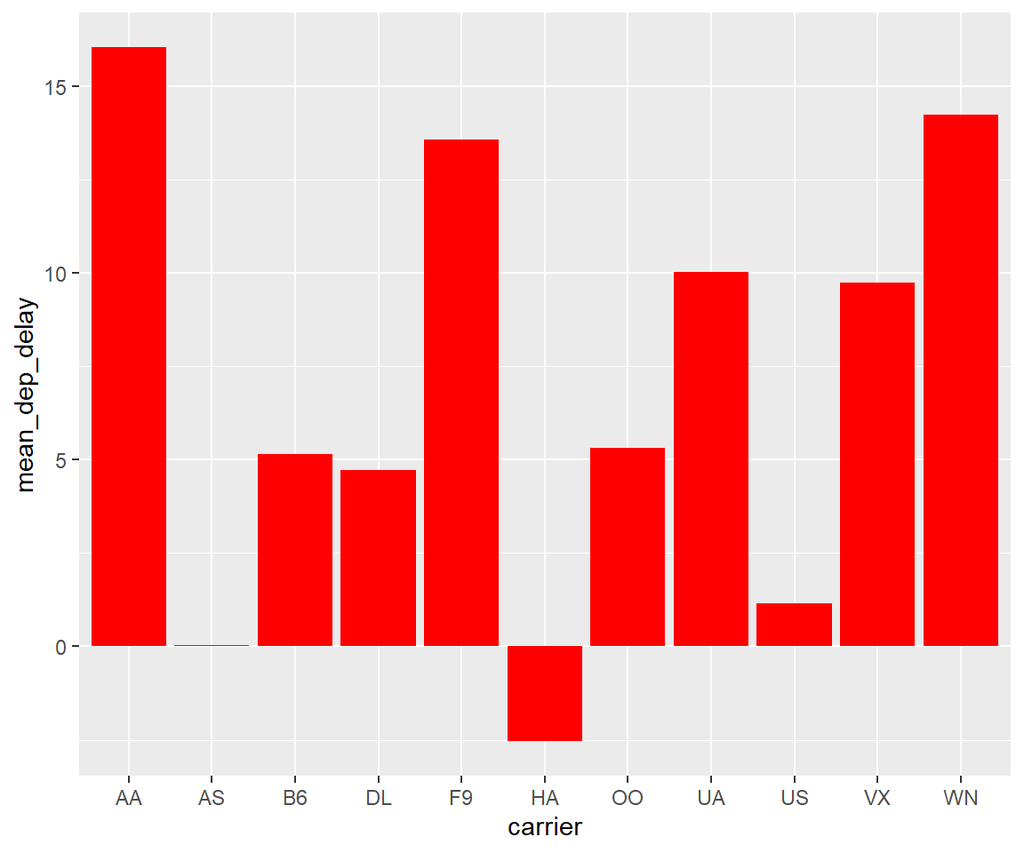

Figure 1: Mean Delays by Airline

```r
mean_delay_by_carrier <- flights %>%
  group_by(carrier) %>%
  summarize(mean_dep_delay = mean(dep_delay))
ggplot(mean_delay_by_carrier, aes(x = carrier, y = mean_dep_delay)) +
  geom_bar(position = "identity", stat = "identity", fill = "red")
```

Here is a reference to this image: Figure 1.

A table linking these carrier codes to airline names is available at https://github.com/ismayc/pnwflights14/blob/master/data/airlines.csv.

**More Figure Stuff**

## Footnotes and Endnotes

You might want to footnote something. [^1] The footnote will be in a smaller font and placed appropriately. Endnotes work in much the same way. More information can be found about both on the CUS site or feel free to reach out to data@reed.edu.

## Bibliographies

Of course you will need to cite things, and you will probably accumulate an armful of sources. There are a variety of tools available for creating a bibliography database (stored with the .bib extension). In addition to BibTeX suggested below, you may want to consider using the free and easy-to-use tool called Zotero. The Reed librarians have created Zotero documentation at https://libguides.reed.edu/citation/zotero. In addition, a tutorial is available from Middlebury College at https://sites.middlebury.edu/zoteromiddlebury/.

*R Markdown* uses *pandoc* (https://pandoc.org/) to build its bibliographies. One nice caveat of this is that you won’t have to do a second compile to load in references as standard LaTeX requires. To cite references in your thesis (after creating your bibliography database), place the reference name inside square brackets and precede it by the “at” symbol. For example, here’s a reference to a book about worrying: (Molina & Borkovec, 1994). This `Molina1994` entry appears in a file called `thesis.bib` in the `bib` folder. This bibliography database file was created by a program called BibTeX. You can call this file something else if you like (look at the YAML header in the main .Rmd file) and, by default, is to placed in the `bib` folder.

For more information about BibTeX and bibliographies, see our CUS site (https://web.reed.edu/cis/help/latex/index.html)[^2]. There are three pages on this topic: *bibtex* (which talks about using BibTeX, at https://web.reed.edu/cis/help/latex/bibtex.html), *bibtexstyles* (about how to find and use the bibliography style that best suits your needs, at https://web.reed.edu/cis/help/latex/bibtexstyles.html) and *bibman* (which covers how to make and maintain a bibliography by hand, without BibTeX, at https://web.reed.edu/cis/help/latex/bibman.html). The last page will not be useful unless you have only a few sources.

If you look at the YAML header at the top of the main .Rmd file you can see that we can specify the style of the bibliography by referencing the appropriate csl file. You can download a variety of different style files at https://www.zotero.org/styles. Make sure to download the file into the csl folder.

**Tips for Bibliographies**

- Like with thesis formatting, the sooner you start compiling your bibliography for something as large as thesis, the better. Typing in source after source is mind-numbing enough; do you really want to do it for hours on end in late April? Think of it as procrastination.
- The cite key (a citation’s label) needs to be unique from the other entries.
- When you have more than one author or editor, you need to separate each author’s name by the word “and” e.g. `Author = {Noble, Sam and Youngberg, Jessica},`.
- Bibliographies made using BibTeX (whether manually or using a manager) accept LaTeX markup, so you can italicize and add symbols as necessary.
- To force capitalization in an article title or where all lowercase is generally used, bracket the capital letter in curly braces.
- You can add a Reed Thesis citation[^3] option. The best way to do this is to use the phdthesis type of citation, and use the optional “type” field to enter “Reed thesis” or “Undergraduate thesis.”

## Anything else?

If you’d like to see examples of other things in this template, please contact the Data @ Reed team (email data@reed.edu) with your suggestions. We love to see people using *R Markdown* for their theses, and are happy to help.

# Feedback loop

To create the feedback loop (to get information back from supervisors) I have began to develop a interactive shiny app within the same structure as the baseline dataset so that there is limited coding needed to create the tidypipes “cycle” of community engagement.

```r
library(knitr)
# knitr::include_graphics(path = here::here("./img/")
```

As computational work takes over our regular management of time over the tradional hard copy “diary”. I like this because important information can not be left in the “local cafe” however as I have used “gmail”, “outlook” and there suites of applications and tools for calenders I have muddled everything up and missed appointments etc.

There is alot of my development work in this section because I have attempted to combine these two packages in a way to document all the counciimgl emails and other work that I have undertaken as part of the `COVID19` pandemic in Australia.

# Visualisation

Generally the concept is to create a baseline dataset of information and then extend this using `dataspice` to create a tidy format of data that can then be modelled and visualised using the `tidyverse` suite of tools.

*Creating timeline charts in R (Generating Timeline charts: Blog online)*

### Action tasks

#### Table 1

```r
table(datBASE1$month, datBASE1$project)
```

```
##
##             council finances invert personal Phd PhD src
##   april           0        6      0        0   0   0   0
##   April           0        0      0        0   0   2   0
##   august          1        4      4       16   2   5   8
##   August          0        0      0        0   0   1   0
##   december        1        3      0        0   0   1   4
##   February        0        0      0        0   0   1   0
##   july            0        3      8        0   0  15   4
##   July            0        0      0        0   0   2   0
##   june            0       13      0        0   0   1   4
##   June            0        0      0        0   0   1   0
##   march           0        9      0        0   0   0   0
##   March           0        0      0        0   0   2   0
##   may             0        3      0        0   0   0   0
##   May             0        0      0        0   0   1   0
##   november        0        0      0        0   0   3   4
##   october         1        0      0        0   0   1   6
##   september       0        3      0        0   0   1  11
```

#### Table 2

```r
table(datBASE1$month, datBASE1$project, datBASE1$status)
```

```
## , ,  = At Risk
##
##
##             council finances invert personal Phd PhD src
##   april           0        0      0        0   0   0   0
##   April           0        0      0        0   0   0   0
##   august          0        1      0        0   0   4   0
##   August          0        0      0        0   0   0   0
##   december        0        0      0        0   0   0   0
##   February        0        0      0        0   0   0   0
##   july            0        3      0        0   0   1   0
##   July            0        0      0        0   0   0   0
##   june            0        1      0        0   0   0   0
##   June            0        0      0        0   0   0   0
##   march           0        0      0        0   0   0   0
##   March           0        0      0        0   0   0   0
##   may             0        0      0        0   0   0   0
##   May             0        0      0        0   0   0   0
##   november        0        0      0        0   0   0   0
##   october         0        0      0        0   0   0   0
##   september       0        3      0        0   0   0   0
##
## , ,  = Complete
##
##
##             council finances invert personal Phd PhD src
##   april           0        6      0        0   0   0   0
##   April           0        0      0        0   0   0   0
##   august          0        0      0        0   0   0   0
##   August          0        0      0        0   0   0   0
##   december        0        0      0        0   0   0   0
##   February        0        0      0        0   0   0   0
##   july            0        0      3        0   0   1   4
##   July            0        0      0        0   0   0   0
##   june            0       12      0        0   0   1   4
##   June            0        0      0        0   0   0   0
##   march           0        9      0        0   0   0   0
##   March           0        0      0        0   0   0   0
##   may             0        3      0        0   0   0   0
##   May             0        0      0        0   0   0   0
```

[output cut: 98 more lines]

```
##   august          1        3      4        0   0   1   8
##   August          0        0      0        0   0   0   0
##   december        1        3      0        0   0   0   4
##   February        0        0      0        0   0   0   0
##   july            0        0      4        0   0  13   0
##   July            0        0      0        0   0   0   0
##   june            0        0      0        0   0   0   0
##   June            0        0      0        0   0   0   0
##   march           0        0      0        0   0   0   0
##   March           0        0      0        0   0   0   0
##   may             0        0      0        0   0   0   0
##   May             0        0      0        0   0   0   0
##   november        0        0      0        0   0   0   4
##   october         1        0      0        0   0   1   6
##   september       0        0      0        0   0   1  11
```

To do this I have created a calendar for each key project/impact/aspect of short-term timeline, objectives, as well as, my career and life projection. To begin with I need to create timelines and other project goals under covid19. I have put this into a single dataset called `dat` here.

## `ggplot2`

### Milestones timeline

“Coverting a dataframe into a timeline”

### Factoring

```r
#factoring
status_levels <- c("Complete", "On Target", "At Risk", "Critical")

status_colors <- c("#0070C0", "#00B050", "#FFC000", "#C00000")

df$status <- factor(df$status, levels=status_levels, ordered=TRUE)
```

### Direction

```r
library(lubridate)
df <- readr::read_csv(here::here('./data/milestones.csv'))
df$date <- with(df, ymd(sprintf('%04d%02d%02d', year, month, 1)))
#direction
positions <- c(0.5, -0.5, 1.0, -1.0, 1.5, -1.5)
directions <- c(1, -1)

line_pos <- data.frame(
    "date"=unique(df$date),
    "position"=rep(positions, length.out=length(unique(df$date))),
    "direction"=rep(directions, length.out=length(unique(df$date)))
)

df <- merge(x=df, y=line_pos, by="date", all = TRUE)
df <- df[with(df, order(date, status)), ]

df$month_count <- ave(df$date==df$date, df$date, FUN=cumsum)
text_offset <- 0.2

df$text_position <- (df$month_count * text_offset * df$direction) + df$position
head(df)
```

|  | date | month | year | milestone | status | position | direction | month_count | text_position |
| --- | --- | --- | --- | --- | --- | --- | --- | --- | --- |
| 1 | 2017-06-01 | 6 | 2017 | Milestone 1 | Complete | 0.5 | 1 | 1 | 0.7 |
| 2 | 2017-07-01 | 7 | 2017 | Milestone 2 | Complete | -0.5 | -1 | 1 | -0.7 |
| 3 | 2017-10-01 | 10 | 2017 | Milestone 3 | Complete | 1.0 | 1 | 1 | 1.2 |
| 4 | 2017-12-01 | 12 | 2017 | Milestone 4 | Complete | -1.0 | -1 | 1 | -1.2 |
| 5 | 2018-01-01 | 1 | 2018 | Milestone 5 | Complete | 1.5 | 1 | 1 | 1.7 |
| 6 | 2018-01-01 | 1 | 2018 | Milestone 6 | Complete | 1.5 | 1 | 2 | 1.9 |

### Counts

```r
text_offset <- 0.2

df$month_count <- ave(df$date==df$date, df$date, FUN=cumsum)
df$text_position <- (df$month_count * text_offset * df$direction) + df$position
head(df)
```

|  | date | month | year | milestone | status | position | direction | month_count | text_position |
| --- | --- | --- | --- | --- | --- | --- | --- | --- | --- |
| 1 | 2017-06-01 | 6 | 2017 | Milestone 1 | Complete | 0.5 | 1 | 1 | 0.7 |
| 2 | 2017-07-01 | 7 | 2017 | Milestone 2 | Complete | -0.5 | -1 | 1 | -0.7 |
| 3 | 2017-10-01 | 10 | 2017 | Milestone 3 | Complete | 1.0 | 1 | 1 | 1.2 |
| 4 | 2017-12-01 | 12 | 2017 | Milestone 4 | Complete | -1.0 | -1 | 1 | -1.2 |
| 5 | 2018-01-01 | 1 | 2018 | Milestone 5 | Complete | 1.5 | 1 | 1 | 1.7 |
| 6 | 2018-01-01 | 1 | 2018 | Milestone 6 | Complete | 1.5 | 1 | 2 | 1.9 |

### Buffering times

```r
month_buffer <- 2

month_date_range <- seq(min(df$date) - months(month_buffer), max(df$date) + months(month_buffer), by='month')
month_format <- format(month_date_range, '%b')
month_df <- data.frame(month_date_range, month_format)
```

### December/January only

```r
year_date_range <- seq(min(df$date) - months(month_buffer), max(df$date) + months(month_buffer), by='year')
year_date_range <- as.Date(
    intersect(
        ceiling_date(year_date_range, unit="year"),
        floor_date(year_date_range, unit="year")
    ),  origin = "1970-01-01"
)
year_format <- format(year_date_range, '%Y')
year_df <- data.frame(year_date_range, year_format)
```

### Interactivity

# Conclusion

If we don’t want Conclusion to have a chapter number next to it, we can add the `{-}` attribute.

**More info**

And here’s some other random info: the first paragraph after a chapter title or section head *shouldn’t be* indented, because indents are to tell the reader that you’re starting a new paragraph. Since that’s obvious after a chapter or section title, proper typesetting doesn’t add an indent there.

# Case studies

I then apply a Bayesian modelling framework to two case studies, incorperating increased complexity from beech forests (Chapter Two) t mixed forest dynamics (Chapter Three) in NZ forests. Each case study consists of high quality CR datasets. The CR study design allows me to encorperate both the proposed ecological processes (e.g. predation) know to drive populations and the observation error (e.g. estimating population size) from the research synthesis.

## Beech Forests

Compare the importance of bottom-up and top-down processes in regulating invasive species in New Zealand forests.

*[publication: Davidson2020-Beech-forests]*

## Mixed Podocarp forests

A more complex set of interacting invasive species.

*[publication: Davidson2020-MPD-forests]*

# Mixed Podocarp forests

I then apply a Bayesian modelling framework to two case studies, increasing in complexity. These case studies incorporate both the proposed ecological processes (e.g. predation) and observation error (e.g. estimating population size) from the research synthesis.

*[publication: Davidson2020-MPD-forests]*

A more complex set of interreacting invasive species.

# Case studies

I then apply a Bayesian modelling framework to two case studies, incorperating increased complexity from beech forests (Chapter Two) t mixed forest dynamics (Chapter Three) in NZ forests. Each case study consists of high quality CR datasets. The CR study design allows me to encorperate both the proposed ecological processes (e.g. predation) know to drive populations and the observation error (e.g. estimating population size) from the research synthesis.

## Beech Forests

Compare the importance of bottom-up and top-down processes in regulating invasive species in New Zealand forests.

### `[Davidson2020-Beech-forests]`

**Title:** Merky forests. What can we expect from stoat control in NZ forests? - Food vs. Predation.

**Status:** [1st draft with Richard](https://www.dropbox.com/s/m5hte0n2vyl1dt2/Davidson_2019_BeechForest_19022019.docx?dl=0)

## Mixed Podocarp forests

A more complex set of interacting invasive species.

### `[Davidson2020-MPD-forests]`

**Title:** Merky forests. What can we expect from stoat control in NZ forests? - Food vs. Predation.

**Status:** [Analysis underway](https://www.dropbox.com/s/fm57ns1jndmkmq1/Davidson_2019_mpd_manuscript.docx?dl=0)

# Consistency with predictions

## Methods predictions:

# Appendix

# The First Appendix

This first appendix includes all of the R chunks of code that were hidden throughout the document (using the `include = FALSE` chunk tag) to help with readibility and/or setup.

**In the main Rmd file**

```r
# This chunk ensures that the thesisdown package is
# installed and loaded. This thesisdown package includes
# the template files for the thesis.
if (!require(remotes)) {
  if (params$`Install needed packages for {thesisdown}`) {
    install.packages("remotes", repos = "https://cran.rstudio.com")
  } else {
    stop(
      paste('You need to run install.packages("remotes")",
            "first in the Console.')
    )
  }
}
if (!require(thesisdown)) {
  if (params$`Install needed packages for {thesisdown}`) {
    remotes::install_github("ismayc/thesisdown")
  } else {
    stop(
      paste(
        "You need to run",
        'remotes::install_github("ismayc/thesisdown")',
        "first in the Console."
      )
    )
  }
}
library(thesisdown)
# Set how wide the R output will go
options(width = 70)
```

```r
# This chunk ensures that the thesisdown package is
# installed and loaded. This thesisdown package includes
# the template files for the thesis and also two functions
# used for labeling and referencing
if (!require(remotes)) {
  if (params$`Install needed packages for {thesisdown}`) {
    install.packages("remotes", repos = "https://cran.rstudio.com")
  } else {
    stop(
      paste(
        'You need to run install.packages("remotes")',
        "first in the Console."
      )
    )
  }
}
if (!require(dplyr)) {
  if (params$`Install needed packages for {thesisdown}`) {
    install.packages("dplyr", repos = "https://cran.rstudio.com")
  } else {
    stop(
      paste(
        'You need to run install.packages("dplyr")',
        "first in the Console."
      )
    )
  }
}
if (!require(ggplot2)) {
  if (params$`Install needed packages for {thesisdown}`) {
    install.packages("ggplot2", repos = "https://cran.rstudio.com")
  } else {
    stop(
      paste(
        'You need to run install.packages("ggplot2")',
        "first in the Console."
      )
    )
  }
}
if (!require(bookdown)) {
  if (params$`Install needed packages for {thesisdown}`) {
    install.packages("bookdown", repos = "https://cran.rstudio.com")
  } else {
    stop(
      paste(
        'You need to run install.packages("bookdown")',
        "first in the Console."
      )
    )
  }
}
if (!require(thesisdown)) {
  if (params$`Install needed packages for {thesisdown}`) {
    remotes::install_github("ismayc/thesisdown")
  } else {
    stop(
      paste(
        "You need to run",
        'remotes::install_github("ismayc/thesisdown")',
        "first in the Console."
      )
    )
  }
}
library(thesisdown)
library(dplyr)
library(ggplot2)
library(knitr)
flights <- read.csv("data/flights.csv", stringsAsFactors = FALSE)
```

# The Second Appendix, for Fun

# Discussion

The computationally reproducible framework I create and apply in this thesis are a key aspect of achieving PFNZ2050. I explain why this is and apply these new reproduciblity measures to replicate theoretical processes and visualise new data to account for dynamic changes in observd outcomes of predator control. This chapter puts my thesis in the context of global control programs.

## `[Davidson2020-PFNZ2050]`

**Title:** *Dealing with Reproducibility for invasive species research in New Zealand*

**Status:** Frameworks working…need to write up.

## Manual References

- Mislan, K. A. S., Jeffrey M. Heer, and Ethan P. White. 2016. “Elevating The Status of Code in Ecology.” Trends in Ecology & Evolution 31 (1): 4–7. https://doi.org/10.1016/j.tree.2015.11.006.
- Ouzzani, Mourad, Hossam Hammady, Zbys Fedorowicz, and Ahmed Elmagarmid. 2016. “Rayyana Web and Mobile App for Systematic Reviews.” Systematic Reviews 5 (1): 210. https://doi.org/10.1186/s13643-016-0384-4.
- Stodden, Victoria, Peixuan Guo, and Zhaokun Ma. 2013. “Toward Reproducible Computational Research: An Empirical Analysis of Data and Code Policy Adoption by Journals.” PLOS ONE 8 (6): e67111. https://doi.org/10.1371/journal.pone.0067111.
- Team, R Core. 2018. “R: A Language and Environment for Statistical Computing.” Vienna, Austria: R Foundation for Statistical Computing.

# References

# References

Submission

3.4. A candidate must sign a declaration that the thesis does notcontain any material published or written by another person except where due reference is made in the text or footnotes.

Material

produced jointly by acandidate and his/her supervisors or others can only be included in the narrative of the thesis if the candidate was explicitly involved in the original work. Any jointly-produced material in the examination submission must be accompanied by astatementclearly indicatingthe candidate’s contribution to the research.

3.5. No material or publications presented for examination for any other degree within this or any other institution will be submitted for assessment unless its incorporation in the thesis is declared in a statement. Content and structural requirements for the thesis

3.6. A doctoral thesis must make a distinctand significantcontribution to knowledge or understanding in the area of research and/or the application of knowledge to the analysis of problems in the study area; and mustafford evidence of originality.

3.7. A masters thesis shall display asound knowledge of the field of the research and include substantialcritical review of the field. 3.8. Subject to permission being obtained from publishers if necessary, the copyright of the thesis is deemed to be vested in the author.The relevant University policy for intellectual property principles as they relate to Higher Degree by Research candidates is the Intellectual Property Policy.

3.9. The followingapplies to the length of the thesis: A thesis submitted for a Doctor of Philosophy degree should not exceed 100,000 words; A thesis submitted for a Professional Doctorate degree should not exceed 60,000 words; A thesis submitted for a Masters by Research degree should not exceed 60,000 words.

3.10. Thesis requirements will in part be dictated by disciplinary requirements and the type of thesis produced.See Higher Degree by Research Thesis Submission and Examination Guidelines for the thesis requirements of submissions for examination, includingspecificguidelines and requirements for the submission ofathesis consisting of published work. Format requirements for the thesis

3.11. The University has aset ofgeneric formattingrequirements for theses[1].These requirements are set on in the Higher Degree by Research ThesisSubmission and Examination Guidelines.

3.12. It is expected that the supervisory panel will provide editorialadvice to the candidate.

3.13. Candidates may use a professional editor in preparingtheir thesis for submission but must strictly follow the guidelines set out in the Higher Degree by Research ThesisSubmission and Examination

Guidelines.

[1]For research theses incorporatingcreative production these formattingrequirements relate to the exegeticalcomponent of the thesis

Angel, E. (2000). *Interactive computer graphics : A top-down approach with OpenGL*. Boston, MA: Addison Wesley Longman.

Angel, E. (2001a). *Batch-file computer graphics : A bottom-up approach with QuickTime*. Boston, MA: Wesley Addison Longman.

Angel, E. (2001b). *Test second book by angel*. Boston, MA: Wesley Addison Longman.

Molina, S. T., & Borkovec, T. D. (1994). The Penn State worry questionnaire: Psychometric properties and associated characteristics. In G. C. L. Davey & F. Tallis (Eds.), *Worrying: Perspectives on theory, assessment and treatment* (pp. 265–283). New York: Wiley.

Noble, S. G. (2002). *Turning images into simple line-art* (Undergraduate thesis). Reed College.

Reed College. (2007). LaTeX your document. Retrieved from https://web.reed.edu/cis/help/LaTeX/index.html

[^1]: footnote text
[^2]: Reed College (2007)
[^3]: Noble (2002)